# Risk Factor Analysis

## Outcome Variable

**Outcome Variable:** wast_rec90d

## Predictor Variables

**Intervention Variable:** exclfeed36

**Adjustment Set:**

unadjusted

## Stratifying Variables

The analysis was stratified on these variable(s):

- agecat
- studyid
- country

## Data Summary

| agecat | studyid | country | exclfeed36 | wast_rec90d | n_cell | n |
| --- | --- | --- | --- | --- | --- | --- |
| 0-24 months | ki0047075b-MAL-ED | BANGLADESH | 0 | 0 | 29 | 122 |
| 0-24 months | ki0047075b-MAL-ED | BANGLADESH | 0 | 1 | 55 | 122 |
| 0-24 months | ki0047075b-MAL-ED | BANGLADESH | 1 | 0 | 15 | 122 |
| 0-24 months | ki0047075b-MAL-ED | BANGLADESH | 1 | 1 | 23 | 122 |
| 0-24 months | ki0047075b-MAL-ED | BRAZIL | 0 | 0 | 6 | 23 |
| 0-24 months | ki0047075b-MAL-ED | BRAZIL | 0 | 1 | 17 | 23 |
| 0-24 months | ki0047075b-MAL-ED | BRAZIL | 1 | 0 | 0 | 23 |
| 0-24 months | ki0047075b-MAL-ED | BRAZIL | 1 | 1 | 0 | 23 |
| 0-24 months | ki0047075b-MAL-ED | INDIA | 0 | 0 | 70 | 177 |
| 0-24 months | ki0047075b-MAL-ED | INDIA | 0 | 1 | 104 | 177 |
| 0-24 months | ki0047075b-MAL-ED | INDIA | 1 | 0 | 0 | 177 |
| 0-24 months | ki0047075b-MAL-ED | INDIA | 1 | 1 | 3 | 177 |
| 0-24 months | ki0047075b-MAL-ED | NEPAL | 0 | 0 | 20 | 93 |
| 0-24 months | ki0047075b-MAL-ED | NEPAL | 0 | 1 | 72 | 93 |
| 0-24 months | ki0047075b-MAL-ED | NEPAL | 1 | 0 | 0 | 93 |
| 0-24 months | ki0047075b-MAL-ED | NEPAL | 1 | 1 | 1 | 93 |
| 0-24 months | ki0047075b-MAL-ED | PERU | 0 | 0 | 6 | 32 |
| 0-24 months | ki0047075b-MAL-ED | PERU | 0 | 1 | 26 | 32 |
| 0-24 months | ki0047075b-MAL-ED | PERU | 1 | 0 | 0 | 32 |
| 0-24 months | ki0047075b-MAL-ED | PERU | 1 | 1 | 0 | 32 |
| 0-24 months | ki0047075b-MAL-ED | SOUTH AFRICA | 0 | 0 | 13 | 78 |
| 0-24 months | ki0047075b-MAL-ED | SOUTH AFRICA | 0 | 1 | 65 | 78 |
| 0-24 months | ki0047075b-MAL-ED | SOUTH AFRICA | 1 | 0 | 0 | 78 |
| 0-24 months | ki0047075b-MAL-ED | SOUTH AFRICA | 1 | 1 | 0 | 78 |
| 0-24 months | ki0047075b-MAL-ED | TANZANIA, UNITED REPUBLIC OF | 0 | 0 | 8 | 45 |
| 0-24 months | ki0047075b-MAL-ED | TANZANIA, UNITED REPUBLIC OF | 0 | 1 | 37 | 45 |
| 0-24 months | ki0047075b-MAL-ED | TANZANIA, UNITED REPUBLIC OF | 1 | 0 | 0 | 45 |
| 0-24 months | ki0047075b-MAL-ED | TANZANIA, UNITED REPUBLIC OF | 1 | 1 | 0 | 45 |
| 0-24 months | ki1000108-CMC-V-BCS-2002 | INDIA | 0 | 0 | 0 | 5 |
| 0-24 months | ki1000108-CMC-V-BCS-2002 | INDIA | 0 | 1 | 0 | 5 |

[output cut: 174 more lines]

The following strata were considered:

- agecat: 0-24 months, studyid: ki0047075b-MAL-ED, country: BANGLADESH
- agecat: 0-24 months, studyid: ki0047075b-MAL-ED, country: BRAZIL
- agecat: 0-24 months, studyid: ki0047075b-MAL-ED, country: INDIA
- agecat: 0-24 months, studyid: ki0047075b-MAL-ED, country: NEPAL
- agecat: 0-24 months, studyid: ki0047075b-MAL-ED, country: PERU
- agecat: 0-24 months, studyid: ki0047075b-MAL-ED, country: SOUTH AFRICA
- agecat: 0-24 months, studyid: ki0047075b-MAL-ED, country: TANZANIA, UNITED REPUBLIC OF
- agecat: 0-24 months, studyid: ki1000108-CMC-V-BCS-2002, country: INDIA
- agecat: 0-24 months, studyid: ki1000108-IRC, country: INDIA
- agecat: 0-24 months, studyid: ki1000109-EE, country: PAKISTAN
- agecat: 0-24 months, studyid: ki1000304b-SAS-FoodSuppl, country: INDIA
- agecat: 0-24 months, studyid: ki1017093b-PROVIDE, country: BANGLADESH
- agecat: 0-24 months, studyid: ki1101329-Keneba, country: GAMBIA
- agecat: 0-24 months, studyid: ki1113344-GMS-Nepal, country: NEPAL
- agecat: 0-24 months, studyid: ki1148112-LCNI-5, country: MALAWI
- agecat: 0-24 months, studyid: kiGH5241-JiVitA-3, country: BANGLADESH
- agecat: 0-24 months, studyid: kiGH5241-JiVitA-4, country: BANGLADESH
- agecat: 0-6 months, studyid: ki0047075b-MAL-ED, country: BANGLADESH
- agecat: 0-6 months, studyid: ki0047075b-MAL-ED, country: BRAZIL
- agecat: 0-6 months, studyid: ki0047075b-MAL-ED, country: INDIA
- agecat: 0-6 months, studyid: ki0047075b-MAL-ED, country: NEPAL
- agecat: 0-6 months, studyid: ki0047075b-MAL-ED, country: PERU
- agecat: 0-6 months, studyid: ki0047075b-MAL-ED, country: SOUTH AFRICA
- agecat: 0-6 months, studyid: ki0047075b-MAL-ED, country: TANZANIA, UNITED REPUBLIC OF
- agecat: 0-6 months, studyid: ki1000108-CMC-V-BCS-2002, country: INDIA
- agecat: 0-6 months, studyid: ki1000108-IRC, country: INDIA
- agecat: 0-6 months, studyid: ki1000109-EE, country: PAKISTAN
- agecat: 0-6 months, studyid: ki1000304b-SAS-FoodSuppl, country: INDIA
- agecat: 0-6 months, studyid: ki1017093b-PROVIDE, country: BANGLADESH
- agecat: 0-6 months, studyid: ki1101329-Keneba, country: GAMBIA
- agecat: 0-6 months, studyid: ki1113344-GMS-Nepal, country: NEPAL
- agecat: 0-6 months, studyid: ki1148112-LCNI-5, country: MALAWI
- agecat: 0-6 months, studyid: kiGH5241-JiVitA-3, country: BANGLADESH
- agecat: 0-6 months, studyid: kiGH5241-JiVitA-4, country: BANGLADESH
- agecat: 6-24 months, studyid: ki0047075b-MAL-ED, country: BANGLADESH
- agecat: 6-24 months, studyid: ki0047075b-MAL-ED, country: BRAZIL
- agecat: 6-24 months, studyid: ki0047075b-MAL-ED, country: INDIA
- agecat: 6-24 months, studyid: ki0047075b-MAL-ED, country: NEPAL
- agecat: 6-24 months, studyid: ki0047075b-MAL-ED, country: PERU
- agecat: 6-24 months, studyid: ki0047075b-MAL-ED, country: SOUTH AFRICA
- agecat: 6-24 months, studyid: ki0047075b-MAL-ED, country: TANZANIA, UNITED REPUBLIC OF
- agecat: 6-24 months, studyid: ki1000108-CMC-V-BCS-2002, country: INDIA
- agecat: 6-24 months, studyid: ki1000108-IRC, country: INDIA
- agecat: 6-24 months, studyid: ki1000109-EE, country: PAKISTAN
- agecat: 6-24 months, studyid: ki1000304b-SAS-FoodSuppl, country: INDIA
- agecat: 6-24 months, studyid: ki1017093b-PROVIDE, country: BANGLADESH
- agecat: 6-24 months, studyid: ki1101329-Keneba, country: GAMBIA
- agecat: 6-24 months, studyid: ki1113344-GMS-Nepal, country: NEPAL
- agecat: 6-24 months, studyid: ki1148112-LCNI-5, country: MALAWI
- agecat: 6-24 months, studyid: kiGH5241-JiVitA-3, country: BANGLADESH
- agecat: 6-24 months, studyid: kiGH5241-JiVitA-4, country: BANGLADESH

### Dropped Strata

Some strata were dropped due to rare outcomes:

- agecat: 0-24 months, studyid: ki0047075b-MAL-ED, country: BRAZIL
- agecat: 0-24 months, studyid: ki0047075b-MAL-ED, country: INDIA
- agecat: 0-24 months, studyid: ki0047075b-MAL-ED, country: NEPAL
- agecat: 0-24 months, studyid: ki0047075b-MAL-ED, country: PERU
- agecat: 0-24 months, studyid: ki0047075b-MAL-ED, country: SOUTH AFRICA
- agecat: 0-24 months, studyid: ki0047075b-MAL-ED, country: TANZANIA, UNITED REPUBLIC OF
- agecat: 0-24 months, studyid: ki1000108-CMC-V-BCS-2002, country: INDIA
- agecat: 0-24 months, studyid: ki1000108-IRC, country: INDIA
- agecat: 0-24 months, studyid: ki1000304b-SAS-FoodSuppl, country: INDIA
- agecat: 0-24 months, studyid: ki1148112-LCNI-5, country: MALAWI
- agecat: 0-6 months, studyid: ki0047075b-MAL-ED, country: BANGLADESH
- agecat: 0-6 months, studyid: ki0047075b-MAL-ED, country: BRAZIL
- agecat: 0-6 months, studyid: ki0047075b-MAL-ED, country: INDIA
- agecat: 0-6 months, studyid: ki0047075b-MAL-ED, country: NEPAL
- agecat: 0-6 months, studyid: ki0047075b-MAL-ED, country: PERU
- agecat: 0-6 months, studyid: ki0047075b-MAL-ED, country: SOUTH AFRICA
- agecat: 0-6 months, studyid: ki0047075b-MAL-ED, country: TANZANIA, UNITED REPUBLIC OF
- agecat: 0-6 months, studyid: ki1000108-CMC-V-BCS-2002, country: INDIA
- agecat: 0-6 months, studyid: ki1000108-IRC, country: INDIA
- agecat: 0-6 months, studyid: ki1000304b-SAS-FoodSuppl, country: INDIA
- agecat: 0-6 months, studyid: ki1017093b-PROVIDE, country: BANGLADESH
- agecat: 0-6 months, studyid: ki1148112-LCNI-5, country: MALAWI
- agecat: 6-24 months, studyid: ki0047075b-MAL-ED, country: BRAZIL
- agecat: 6-24 months, studyid: ki0047075b-MAL-ED, country: INDIA
- agecat: 6-24 months, studyid: ki0047075b-MAL-ED, country: NEPAL
- agecat: 6-24 months, studyid: ki0047075b-MAL-ED, country: PERU
- agecat: 6-24 months, studyid: ki0047075b-MAL-ED, country: SOUTH AFRICA
- agecat: 6-24 months, studyid: ki0047075b-MAL-ED, country: TANZANIA, UNITED REPUBLIC OF
- agecat: 6-24 months, studyid: ki1000108-CMC-V-BCS-2002, country: INDIA
- agecat: 6-24 months, studyid: ki1000108-IRC, country: INDIA
- agecat: 6-24 months, studyid: ki1000304b-SAS-FoodSuppl, country: INDIA
- agecat: 6-24 months, studyid: ki1148112-LCNI-5, country: MALAWI
- agecat: 6-24 months, studyid: kiGH5241-JiVitA-3, country: BANGLADESH

## Methods Detail

We’re interested in the causal parameters $E[Y_a]$ for all values of $a \in \mathcal{A}$. These parameters represent the mean outcome if, possibly contrary to fact, we intervened to set all units to have $A=a$. Under the randomization and positivity assumptions, these are identified by the statistical parameters $\psi_a=E_W[E_{Y|A,W}(Y|A=a,W)]$. In addition, we’re interested in the mean of $Y$, $E[Y]$ under no intervention (the observed mean). We will estimate these parameters by using SuperLearner to fit the relevant likelihood factors – $E_{Y|A,W}(Y|A=a,W)$ and $p(A=a|W)$, and then updating our likelihood fit using a joint TMLE.

For unadjusted analyses ($W=\{\}$), initial likelihoods were estimated using Lrnr_glm to estimate the simple $E(Y|A)$ and Lrnr_mean to estimate $p(A)$. For adjusted analyses, a small library containing Lrnr_glmnet, Lrnr_xgboost, and Lrnr_mean was used.

Having estimated these parameters, we will then use the delta method to estimate relative risks and attributable risks relative to a prespecified baseline level of $A$.

# Results Detail

## Results Plots

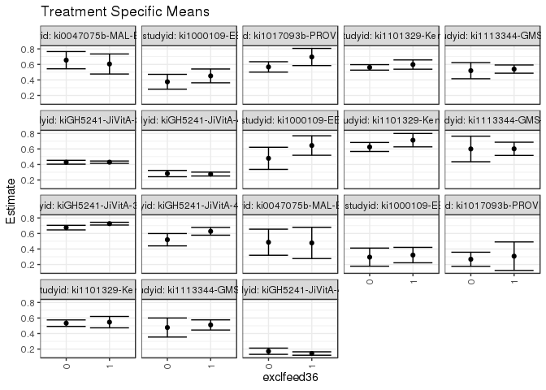

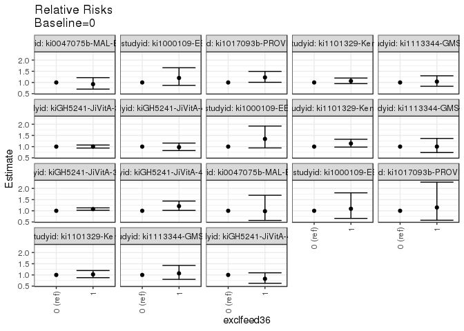

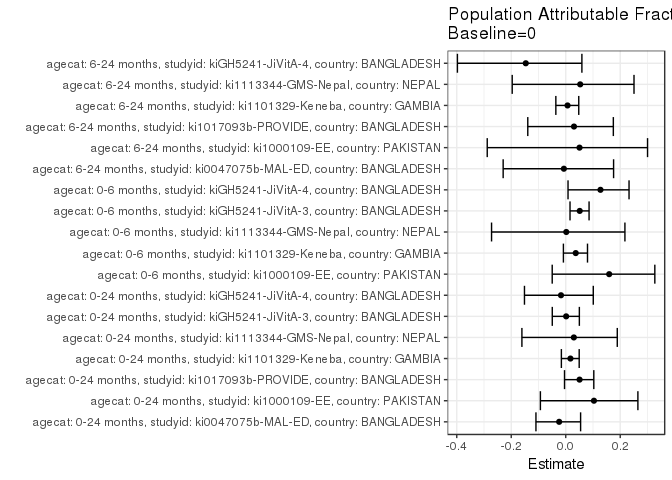

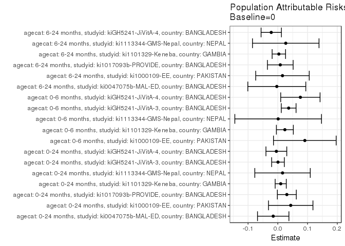

## Results Table

### Parameter: TSM

| agecat | studyid | country | intervention_level | baseline_level | estimate | ci_lower | ci_upper |
| --- | --- | --- | --- | --- | --- | --- | --- |
| 0-24 months | ki0047075b-MAL-ED | BANGLADESH | 0 | NA | 0.6547619 | 0.5435887 | 0.7659351 |
| 0-24 months | ki0047075b-MAL-ED | BANGLADESH | 1 | NA | 0.6052632 | 0.4761138 | 0.7344125 |
| 0-24 months | ki1000109-EE | PAKISTAN | 0 | NA | 0.3761468 | 0.2803097 | 0.4719839 |
| 0-24 months | ki1000109-EE | PAKISTAN | 1 | NA | 0.4520548 | 0.3633123 | 0.5407973 |
| 0-24 months | ki1017093b-PROVIDE | BANGLADESH | 0 | NA | 0.5675676 | 0.5006323 | 0.6345028 |
| 0-24 months | ki1017093b-PROVIDE | BANGLADESH | 1 | NA | 0.6956522 | 0.5852007 | 0.8061036 |
| 0-24 months | ki1101329-Keneba | GAMBIA | 0 | NA | 0.5615819 | 0.5262507 | 0.5969132 |
| 0-24 months | ki1101329-Keneba | GAMBIA | 1 | NA | 0.5981595 | 0.5385113 | 0.6578078 |
| 0-24 months | ki1113344-GMS-Nepal | NEPAL | 0 | NA | 0.5196078 | 0.4155941 | 0.6236215 |
| 0-24 months | ki1113344-GMS-Nepal | NEPAL | 1 | NA | 0.5396040 | 0.4864787 | 0.5927292 |
| 0-24 months | kiGH5241-JiVitA-3 | BANGLADESH | 0 | NA | 0.4285714 | 0.4037447 | 0.4533981 |
| 0-24 months | kiGH5241-JiVitA-3 | BANGLADESH | 1 | NA | 0.4294552 | 0.4144830 | 0.4444273 |
| 0-24 months | kiGH5241-JiVitA-4 | BANGLADESH | 0 | NA | 0.2830189 | 0.2424016 | 0.3236362 |
| 0-24 months | kiGH5241-JiVitA-4 | BANGLADESH | 1 | NA | 0.2764165 | 0.2511944 | 0.3016387 |
| 0-6 months | ki1000109-EE | PAKISTAN | 0 | NA | 0.4791667 | 0.3368869 | 0.6214464 |
| 0-6 months | ki1000109-EE | PAKISTAN | 1 | NA | 0.6440678 | 0.5183967 | 0.7697389 |
| 0-6 months | ki1101329-Keneba | GAMBIA | 0 | NA | 0.6250000 | 0.5669756 | 0.6830244 |
| 0-6 months | ki1101329-Keneba | GAMBIA | 1 | NA | 0.7128713 | 0.6268302 | 0.7989124 |
| 0-6 months | ki1113344-GMS-Nepal | NEPAL | 0 | NA | 0.6000000 | 0.4351707 | 0.7648293 |
| 0-6 months | ki1113344-GMS-Nepal | NEPAL | 1 | NA | 0.6015625 | 0.5163730 | 0.6867520 |
| 0-6 months | kiGH5241-JiVitA-3 | BANGLADESH | 0 | NA | 0.6757039 | 0.6460928 | 0.7053149 |
| 0-6 months | kiGH5241-JiVitA-3 | BANGLADESH | 1 | NA | 0.7263581 | 0.7088264 | 0.7438899 |
| 0-6 months | kiGH5241-JiVitA-4 | BANGLADESH | 0 | NA | 0.5197368 | 0.4402341 | 0.5992396 |
| 0-6 months | kiGH5241-JiVitA-4 | BANGLADESH | 1 | NA | 0.6277778 | 0.5777944 | 0.6777611 |
| 6-24 months | ki0047075b-MAL-ED | BANGLADESH | 0 | NA | 0.4871795 | 0.3190946 | 0.6552644 |
| 6-24 months | ki0047075b-MAL-ED | BANGLADESH | 1 | NA | 0.4782609 | 0.2766858 | 0.6798359 |
| 6-24 months | ki1000109-EE | PAKISTAN | 0 | NA | 0.2950820 | 0.1783533 | 0.4118106 |
| 6-24 months | ki1000109-EE | PAKISTAN | 1 | NA | 0.3218391 | 0.2226817 | 0.4209965 |
| 6-24 months | ki1017093b-PROVIDE | BANGLADESH | 0 | NA | 0.2680412 | 0.1773699 | 0.3587126 |
| 6-24 months | ki1017093b-PROVIDE | BANGLADESH | 1 | NA | 0.3076923 | 0.1243207 | 0.4910639 |
| 6-24 months | ki1101329-Keneba | GAMBIA | 0 | NA | 0.5334421 | 0.4918549 | 0.5750292 |
| 6-24 months | ki1101329-Keneba | GAMBIA | 1 | NA | 0.5466667 | 0.4735346 | 0.6197988 |
| 6-24 months | ki1113344-GMS-Nepal | NEPAL | 0 | NA | 0.4776119 | 0.3548655 | 0.6003584 |
| 6-24 months | ki1113344-GMS-Nepal | NEPAL | 1 | NA | 0.5108696 | 0.4455959 | 0.5761433 |
| 6-24 months | kiGH5241-JiVitA-4 | BANGLADESH | 0 | NA | 0.1723077 | 0.1320225 | 0.2125929 |
| 6-24 months | kiGH5241-JiVitA-4 | BANGLADESH | 1 | NA | 0.1427061 | 0.1207968 | 0.1646155 |

### Parameter: E(Y)

| agecat | studyid | country | intervention_level | baseline_level | estimate | ci_lower | ci_upper |
| --- | --- | --- | --- | --- | --- | --- | --- |
| 0-24 months | ki0047075b-MAL-ED | BANGLADESH | NA | NA | 0.6393443 | 0.5530901 | 0.7255985 |
| 0-24 months | ki1000109-EE | PAKISTAN | NA | NA | 0.4196078 | 0.3541827 | 0.4850330 |
| 0-24 months | ki1017093b-PROVIDE | BANGLADESH | NA | NA | 0.5979381 | 0.5402414 | 0.6556349 |
| 0-24 months | ki1101329-Keneba | GAMBIA | NA | NA | 0.5714286 | 0.5409902 | 0.6018670 |
| 0-24 months | ki1113344-GMS-Nepal | NEPAL | NA | NA | 0.5355731 | 0.4882587 | 0.5828875 |
| 0-24 months | kiGH5241-JiVitA-3 | BANGLADESH | NA | NA | 0.4292213 | 0.4164001 | 0.4420426 |
| 0-24 months | kiGH5241-JiVitA-4 | BANGLADESH | NA | NA | 0.2781828 | 0.2567503 | 0.2996153 |
| 0-6 months | ki1000109-EE | PAKISTAN | NA | NA | 0.5700935 | 0.4742263 | 0.6659606 |
| 0-6 months | ki1101329-Keneba | GAMBIA | NA | NA | 0.6487936 | 0.6002638 | 0.6973233 |
| 0-6 months | ki1113344-GMS-Nepal | NEPAL | NA | NA | 0.6012270 | 0.5255442 | 0.6769098 |
| 0-6 months | kiGH5241-JiVitA-3 | BANGLADESH | NA | NA | 0.7122532 | 0.6971343 | 0.7273720 |
| 0-6 months | kiGH5241-JiVitA-4 | BANGLADESH | NA | NA | 0.5957031 | 0.5531528 | 0.6382534 |
| 6-24 months | ki0047075b-MAL-ED | BANGLADESH | NA | NA | 0.4838710 | 0.3544124 | 0.6133295 |
| 6-24 months | ki1000109-EE | PAKISTAN | NA | NA | 0.3108108 | 0.2352987 | 0.3863229 |
| 6-24 months | ki1017093b-PROVIDE | BANGLADESH | NA | NA | 0.2764228 | 0.1950773 | 0.3577682 |
| 6-24 months | ki1101329-Keneba | GAMBIA | NA | NA | 0.5369928 | 0.5007974 | 0.5731883 |
| 6-24 months | ki1113344-GMS-Nepal | NEPAL | NA | NA | 0.5043732 | 0.4466684 | 0.5620780 |
| 6-24 months | kiGH5241-JiVitA-4 | BANGLADESH | NA | NA | 0.1502754 | 0.1309788 | 0.1695719 |

### Parameter: RR

| agecat | studyid | country | intervention_level | baseline_level | estimate | ci_lower | ci_upper |
| --- | --- | --- | --- | --- | --- | --- | --- |
| 0-24 months | ki0047075b-MAL-ED | BANGLADESH | 0 | 0 | 1.0000000 | 1.0000000 | 1.000000 |
| 0-24 months | ki0047075b-MAL-ED | BANGLADESH | 1 | 0 | 0.9244019 | 0.7033939 | 1.214851 |
| 0-24 months | ki1000109-EE | PAKISTAN | 0 | 0 | 1.0000000 | 1.0000000 | 1.000000 |
| 0-24 months | ki1000109-EE | PAKISTAN | 1 | 0 | 1.2018042 | 0.8710903 | 1.658075 |
| 0-24 months | ki1017093b-PROVIDE | BANGLADESH | 0 | 0 | 1.0000000 | 1.0000000 | 1.000000 |
| 0-24 months | ki1017093b-PROVIDE | BANGLADESH | 1 | 0 | 1.2256729 | 1.0055590 | 1.493969 |
| 0-24 months | ki1101329-Keneba | GAMBIA | 0 | 0 | 1.0000000 | 1.0000000 | 1.000000 |
| 0-24 months | ki1101329-Keneba | GAMBIA | 1 | 0 | 1.0651331 | 0.9466669 | 1.198424 |
| 0-24 months | ki1113344-GMS-Nepal | NEPAL | 0 | 0 | 1.0000000 | 1.0000000 | 1.000000 |
| 0-24 months | ki1113344-GMS-Nepal | NEPAL | 1 | 0 | 1.0384831 | 0.8307919 | 1.298096 |
| 0-24 months | kiGH5241-JiVitA-3 | BANGLADESH | 0 | 0 | 1.0000000 | 1.0000000 | 1.000000 |
| 0-24 months | kiGH5241-JiVitA-3 | BANGLADESH | 1 | 0 | 1.0020620 | 0.9365512 | 1.072155 |
| 0-24 months | kiGH5241-JiVitA-4 | BANGLADESH | 0 | 0 | 1.0000000 | 1.0000000 | 1.000000 |
| 0-24 months | kiGH5241-JiVitA-4 | BANGLADESH | 1 | 0 | 0.9766718 | 0.8239249 | 1.157736 |
| 0-6 months | ki1000109-EE | PAKISTAN | 0 | 0 | 1.0000000 | 1.0000000 | 1.000000 |
| 0-6 months | ki1000109-EE | PAKISTAN | 1 | 0 | 1.3441415 | 0.9421617 | 1.917629 |
| 0-6 months | ki1101329-Keneba | GAMBIA | 0 | 0 | 1.0000000 | 1.0000000 | 1.000000 |
| 0-6 months | ki1101329-Keneba | GAMBIA | 1 | 0 | 1.1405941 | 0.9794905 | 1.328195 |
| 0-6 months | ki1113344-GMS-Nepal | NEPAL | 0 | 0 | 1.0000000 | 1.0000000 | 1.000000 |
| 0-6 months | ki1113344-GMS-Nepal | NEPAL | 1 | 0 | 1.0026042 | 0.7360426 | 1.365702 |
| 0-6 months | kiGH5241-JiVitA-3 | BANGLADESH | 0 | 0 | 1.0000000 | 1.0000000 | 1.000000 |
| 0-6 months | kiGH5241-JiVitA-3 | BANGLADESH | 1 | 0 | 1.0749652 | 1.0225080 | 1.130114 |
| 0-6 months | kiGH5241-JiVitA-4 | BANGLADESH | 0 | 0 | 1.0000000 | 1.0000000 | 1.000000 |
| 0-6 months | kiGH5241-JiVitA-4 | BANGLADESH | 1 | 0 | 1.2078762 | 1.0165512 | 1.435210 |
| 6-24 months | ki0047075b-MAL-ED | BANGLADESH | 0 | 0 | 1.0000000 | 1.0000000 | 1.000000 |
| 6-24 months | ki0047075b-MAL-ED | BANGLADESH | 1 | 0 | 0.9816934 | 0.5692742 | 1.692896 |
| 6-24 months | ki1000109-EE | PAKISTAN | 0 | 0 | 1.0000000 | 1.0000000 | 1.000000 |
| 6-24 months | ki1000109-EE | PAKISTAN | 1 | 0 | 1.0906769 | 0.6603165 | 1.801524 |
| 6-24 months | ki1017093b-PROVIDE | BANGLADESH | 0 | 0 | 1.0000000 | 1.0000000 | 1.000000 |
| 6-24 months | ki1017093b-PROVIDE | BANGLADESH | 1 | 0 | 1.1479290 | 0.5784531 | 2.278043 |
| 6-24 months | ki1101329-Keneba | GAMBIA | 0 | 0 | 1.0000000 | 1.0000000 | 1.000000 |
| 6-24 months | ki1101329-Keneba | GAMBIA | 1 | 0 | 1.0247910 | 0.8777513 | 1.196463 |
| 6-24 months | ki1113344-GMS-Nepal | NEPAL | 0 | 0 | 1.0000000 | 1.0000000 | 1.000000 |
| 6-24 months | ki1113344-GMS-Nepal | NEPAL | 1 | 0 | 1.0696332 | 0.8027241 | 1.425291 |
| 6-24 months | kiGH5241-JiVitA-4 | BANGLADESH | 0 | 0 | 1.0000000 | 1.0000000 | 1.000000 |
| 6-24 months | kiGH5241-JiVitA-4 | BANGLADESH | 1 | 0 | 0.8282052 | 0.6261027 | 1.095545 |

### Parameter: PAR

| agecat | studyid | country | intervention_level | baseline_level | estimate | ci_lower | ci_upper |
| --- | --- | --- | --- | --- | --- | --- | --- |
| 0-24 months | ki0047075b-MAL-ED | BANGLADESH | 0 | NA | -0.0154176 | -0.0682071 | 0.0373718 |
| 0-24 months | ki1000109-EE | PAKISTAN | 0 | NA | 0.0434611 | -0.0312942 | 0.1182163 |
| 0-24 months | ki1017093b-PROVIDE | BANGLADESH | 0 | NA | 0.0303706 | -0.0014983 | 0.0622394 |
| 0-24 months | ki1101329-Keneba | GAMBIA | 0 | NA | 0.0098467 | -0.0088409 | 0.0285342 |
| 0-24 months | ki1113344-GMS-Nepal | NEPAL | 0 | NA | 0.0159653 | -0.0772770 | 0.1092075 |
| 0-24 months | kiGH5241-JiVitA-3 | BANGLADESH | 0 | NA | 0.0006499 | -0.0206717 | 0.0219715 |
| 0-24 months | kiGH5241-JiVitA-4 | BANGLADESH | 0 | NA | -0.0048360 | -0.0398603 | 0.0301883 |
| 0-6 months | ki1000109-EE | PAKISTAN | 0 | NA | 0.0909268 | -0.0144892 | 0.1963427 |
| 0-6 months | ki1101329-Keneba | GAMBIA | 0 | NA | 0.0237936 | -0.0046956 | 0.0522827 |
| 0-6 months | ki1113344-GMS-Nepal | NEPAL | 0 | NA | 0.0012270 | -0.1444749 | 0.1469289 |
| 0-6 months | kiGH5241-JiVitA-3 | BANGLADESH | 0 | NA | 0.0365493 | 0.0117078 | 0.0613909 |
| 0-6 months | kiGH5241-JiVitA-4 | BANGLADESH | 0 | NA | 0.0759663 | 0.0097975 | 0.1421351 |
| 6-24 months | ki0047075b-MAL-ED | BANGLADESH | 0 | NA | -0.0033085 | -0.1007799 | 0.0941628 |
| 6-24 months | ki1000109-EE | PAKISTAN | 0 | NA | 0.0157288 | -0.0742746 | 0.1057323 |
| 6-24 months | ki1017093b-PROVIDE | BANGLADESH | 0 | NA | 0.0083815 | -0.0348546 | 0.0516177 |
| 6-24 months | ki1101329-Keneba | GAMBIA | 0 | NA | 0.0035508 | -0.0190284 | 0.0261299 |
| 6-24 months | ki1113344-GMS-Nepal | NEPAL | 0 | NA | 0.0267612 | -0.0850927 | 0.1386151 |
| 6-24 months | kiGH5241-JiVitA-4 | BANGLADESH | 0 | NA | -0.0220323 | -0.0562007 | 0.0121360 |

### Parameter: PAF

| agecat | studyid | country | intervention_level | baseline_level | estimate | ci_lower | ci_upper |
| --- | --- | --- | --- | --- | --- | --- | --- |
| 0-24 months | ki0047075b-MAL-ED | BANGLADESH | 0 | NA | -0.0241148 | -0.1093432 | 0.0545658 |
| 0-24 months | ki1000109-EE | PAKISTAN | 0 | NA | 0.1035754 | -0.0930311 | 0.2648177 |
| 0-24 months | ki1017093b-PROVIDE | BANGLADESH | 0 | NA | 0.0507922 | -0.0044588 | 0.1030040 |
| 0-24 months | ki1101329-Keneba | GAMBIA | 0 | NA | 0.0172316 | -0.0160123 | 0.0493878 |
| 0-24 months | ki1113344-GMS-Nepal | NEPAL | 0 | NA | 0.0298097 | -0.1608701 | 0.1891692 |
| 0-24 months | kiGH5241-JiVitA-3 | BANGLADESH | 0 | NA | 0.0015142 | -0.0494172 | 0.0499737 |
| 0-24 months | kiGH5241-JiVitA-4 | BANGLADESH | 0 | NA | -0.0173844 | -0.1514549 | 0.1010756 |
| 0-6 months | ki1000109-EE | PAKISTAN | 0 | NA | 0.1594945 | -0.0496491 | 0.3269661 |
| 0-6 months | ki1101329-Keneba | GAMBIA | 0 | NA | 0.0366736 | -0.0085500 | 0.0798693 |
| 0-6 months | ki1113344-GMS-Nepal | NEPAL | 0 | NA | 0.0020408 | -0.2722617 | 0.2172031 |
| 0-6 months | kiGH5241-JiVitA-3 | BANGLADESH | 0 | NA | 0.0513151 | 0.0157242 | 0.0856190 |
| 0-6 months | kiGH5241-JiVitA-4 | BANGLADESH | 0 | NA | 0.1275237 | 0.0084015 | 0.2323357 |
| 6-24 months | ki0047075b-MAL-ED | BANGLADESH | 0 | NA | -0.0068376 | -0.2296774 | 0.1756196 |
| 6-24 months | ki1000109-EE | PAKISTAN | 0 | NA | 0.0506058 | -0.2881237 | 0.3002619 |
| 6-24 months | ki1017093b-PROVIDE | BANGLADESH | 0 | NA | 0.0303214 | -0.1393171 | 0.1747016 |
| 6-24 months | ki1101329-Keneba | GAMBIA | 0 | NA | 0.0066123 | -0.0363144 | 0.0477609 |
| 6-24 months | ki1113344-GMS-Nepal | NEPAL | 0 | NA | 0.0530584 | -0.1964744 | 0.2505495 |
| 6-24 months | kiGH5241-JiVitA-4 | BANGLADESH | 0 | NA | -0.1466130 | -0.3975992 | 0.0593002 |